# TFIDF_PCA_KMeans

2018/07/24

## 唐詩作者分析

資料取自五位唐代詩人(白居易,杜甫,李白,孟浩然,王維)的 五言/七言 絕句/律詩

### Import Library

```r
library(tm)
library(tmcn)
library(Matrix)
library(wordcloud)
library(bitops)
library(httr)
library(RCurl)
library(XML)
library(NLP)
library(jiebaRD)
library(jiebaR)
library(devtools)
install_github("ggbiplot", "vqv")
library(scales)
library(grid)
library(ggbiplot)
library(factoextra)
```

### 資料爬取

- 已先行使用python修改網路上的範例code進行爬取，詳見scrapy_poem.py
- 另將檔案由簡體轉為繁體
- 檔案存於 ./data/poem

## TFIDF

1. 建立文本資料結構與基本文字清洗

```r
d.corpus <- Corpus( DirSource("./data/poem", encoding = "UTF-8"))
d.corpus <- tm_map(d.corpus, removePunctuation) #移除標點符號
d.corpus <- tm_map(d.corpus, removeNumbers) #移除數字
#d.corpus <- tm_map(d.corpus,stripWhitespace) #消除空格
#d.corpus <- tm_map(d.corpus, function(word) { # 移除大小寫
#  gsub("[A-Za-z0-9]", "", word)
#})
```

2. 進行斷詞

```r
mixseg = worker()
#斷詞
jieba_tokenizer = function(d)
{
  unlist( segment(d[[1]], mixseg) )
}
seg = lapply(d.corpus, jieba_tokenizer)

#計數
count_token = function(d)
{
  as.data.frame(table(d))
}
tokens = lapply(seg, count_token)
```

3. 依照作者建立文本矩陣 TermDocumentMatrix(TDM)

```r
# TDM
n = length(seg)
TDM = tokens[[1]]
colNames <- c('白居易','杜甫','李白','孟浩然','王維')
for( id in c(2:n) )
{
  TDM = merge(TDM, tokens[[id]], by="d", all = TRUE)
  names(TDM) = c('d', colNames[1:id])
}

TDM[is.na(TDM)] <- 0 #將NA填0

library(knitr)
kable(head(TDM))
```

| d | 白居易 | 杜甫 | 李白 | 孟浩然 | 王維 |
| --- | --- | --- | --- | --- | --- |
| 一 | 9 | 7 | 7 | 4 | 9 |
| 一入 | 1 | 0 | 0 | 0 | 0 |
| 一大 | 1 | 0 | 0 | 0 | 0 |
| 一斗 | 1 | 0 | 0 | 0 | 0 |
| 一日 | 1 | 0 | 2 | 1 | 0 |
| 一去 | 1 | 0 | 1 | 0 | 0 |

```r
kable(tail(TDM))
```

|  | d | 白居易 | 杜甫 | 李白 | 孟浩然 | 王維 |
| --- | --- | --- | --- | --- | --- | --- |
| 11451 | 驟馬 | 0 | 0 | 0 | 0 | 1 |
| 11452 | 鬢髮 | 0 | 0 | 0 | 0 | 1 |
| 11453 | 籬間 | 0 | 0 | 0 | 0 | 1 |
| 11454 | 觀世得 | 0 | 0 | 0 | 0 | 1 |
| 11455 | 鑾輿 | 0 | 0 | 0 | 0 | 3 |
| 11456 | 鬱金 | 0 | 0 | 0 | 0 | 1 |

4. 將TDM 轉成 TF-IDF

```r
tf <- apply(as.matrix(TDM[,2:(n+1)]), 2, sum) #直向相加計算總數

idfCal <- function(word_doc)
{
  log2( n / nnzero(word_doc) )
}
idf <- apply(as.matrix(TDM[,2:(n+1)]), 1, idfCal)

doc.tfidf <- TDM

tempY = matrix(rep(c(as.matrix(tf)), each = length(idf)), nrow = length(idf))
tempX = matrix(rep(c(as.matrix(idf)), each = length(tf)), ncol = length(tf), byrow = TRUE)
doc.tfidf[,2:(n+1)] <- (doc.tfidf[,2:(n+1)] / tempY) * tempX

#刪除不重要(td-idf=0)的字
stopLine = rowSums(doc.tfidf[,2:(n+1)])
delID = which(stopLine == 0)

kable(head(doc.tfidf[delID,1]))
```

| x |
| --- |
| 一 |
| 人 |
| 入 |
| 上 |
| 下 |
| 久 |

```r
kable(tail(doc.tfidf[delID,1]))
```

| x |
| --- |
| 隨 |
| 歸 |
| 繞 |
| 難 |
| 聽 |
| 豔 |

```r
# final result
TDM = TDM[-delID,]
doc.tfidf = doc.tfidf[-delID,]
```

5. TF-IDF 各作者文章取得的重要關鍵字

```r
TopWords = data.frame()
for( id in c(1:n) )
{
  dayMax = order(doc.tfidf[,id+1], decreasing = TRUE)
  showResult = t(as.data.frame(doc.tfidf[dayMax[1:10],1])) #取前10
  TopWords = rbind(TopWords, showResult)
}
rownames(TopWords) = colnames(doc.tfidf)[2:(n+1)]
TopWords = droplevels(TopWords)
kable(TopWords)
```

|  | V1 | V2 | V3 | V4 | V5 | V6 | V7 | V8 | V9 | V10 |
| --- | --- | --- | --- | --- | --- | --- | --- | --- | --- | --- |
| 白居易 | 慵 | 身 | 伴 | 夜深 | 思量 | 紫薇 | 氣味 | 被 | 一覺 | 三度 |
| 杜甫 | 戎馬 | 無數 | 大 | 永夜 | 汝 | 百草 | 老病 | 涕淚 | 旌旗 | 眼 |
| 李白 | 青天 | 白露 | 金陵 | 三千里 | 長門 | 彩雲 | 掛 | 紫煙 | 殿 | 嘆息 |
| 孟浩然 | 鄉園 | 方知 | 左右 | 依然 | 客中 | 柏 | 海 | 掛席 | 鹿門 | 嶂 |
| 王維 | 迎 | 飛鳥 | 闕 | 客舍 | 帝城 | 崇梵僧 | 淼 | 行人 | 上苑 | 中春樹 |

6. Query of Words 可隨意查詢字組在每個作者文章的TF-IDF, 這邊以“美酒”, “夕陽”, “故人”, “老翁”, “西風”, “琵琶”五組字為範例

```r
query.tfidf <- function(q){
  q.tfidf <- doc.tfidf[doc.tfidf$d==q, ]
  return (q.tfidf)
}

query=c("美酒", "夕陽", "故人", "老翁", "西風", "琵琶")
result = query.tfidf(query[1])
for ( id in c(2:length(query)) )
{
  q.tfidf = query.tfidf(query[id])
  result = rbind(result, q.tfidf)
}
result
```

```
##         d       白居易         杜甫         李白       孟浩然         王維
## 6583 美酒 0.0000000000 0.0000000000 0.0011430420 0.0003043813 0.0000000000
## 132  夕陽 0.0001590554 0.0000702593 0.0000000000 0.0005188802 0.0001575762
## 3905 故人 0.0000000000 0.0000702593 0.0004871372 0.0008895089 0.0004727285
## 669  老翁 0.0006531265 0.0002885046 0.0000000000 0.0000000000 0.0000000000
## 712  西風 0.0006531265 0.0000000000 0.0000000000 0.0003043813 0.0000000000
## 1953 琵琶 0.0001820567 0.0000000000 0.0001593095 0.0001696904 0.0000000000
```

7. Cosine Similiarity 比較各作者間的相關性，這邊將李白設為1做為比較對象

```r
cos <- function(x, y){
  return (x %*% y / sqrt(x %*% x * y %*% y))[1, 1]
}
# compare with 李白
docs.cos.sim <- apply(doc.tfidf[,2:6], 2, cos, y = doc.tfidf[,4])
docs.cos.sim
```

```
##     白居易       杜甫       李白     孟浩然       王維
## 0.03745070 0.04694240 1.00000000 0.05516476 0.04746015
```

似乎沒有誰比較有相關的感覺

8. 文字雲

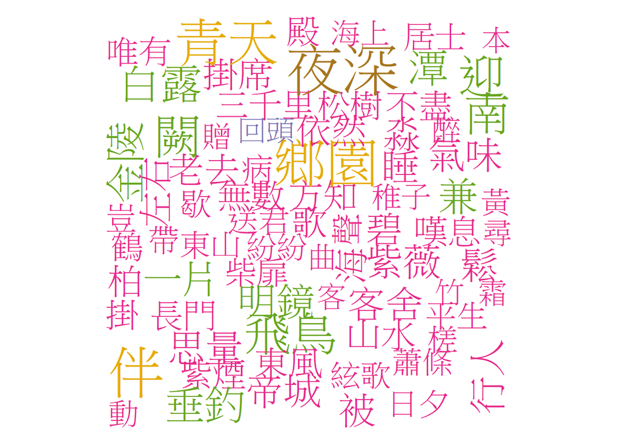

```r
library(wordcloud)
rownames(doc.tfidf) = doc.tfidf$d
f <- sort(rowSums(doc.tfidf[,2:6]), decreasing = T)
docs.df <- data.frame(
  word = names(f),
  freq = f
)
wordcloud(docs.df$word, docs.df$freq, scale=c(5,0.1),max.words=100,
          random.order=TRUE, random.color=FALSE,
          rot.per=.1, colors=brewer.pal(8, "Dark2"),
          ordered.colors=FALSE,use.r.layout=FALSE,
          fixed.asp=TRUE)
```

可以看到各組字詞出現次數太過相近，很有可能是資料收集不足，且唐詩切詞比起我們現代的語言更有難度

## PCA

1. 降維

```r
t = t(doc.tfidf) #轉置
t = t[-1,] #刪除第一列
t = apply(t, 2, as.numeric) #由'character'轉成'numeric'

#PCA
pcat = prcomp(t)
g <- ggbiplot(pcat, obs.scale = 1, var.scale = 1, ellipse = TRUE, circle = TRUE)
# g
```

2. 作圖

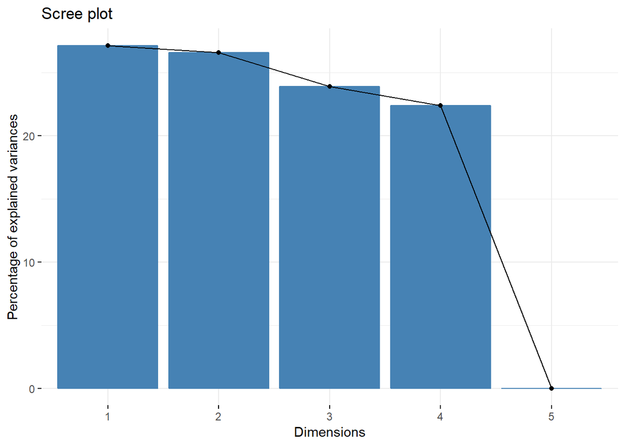

```r
fviz_eig(pcat)
```

**陡坡圖(Scree plot)-凱莎原則**  
將特徵值對主成份個數做圖，尋找出肘點(指由坡度變為較平緩的轉折點)，即為應保留的主成份個數。

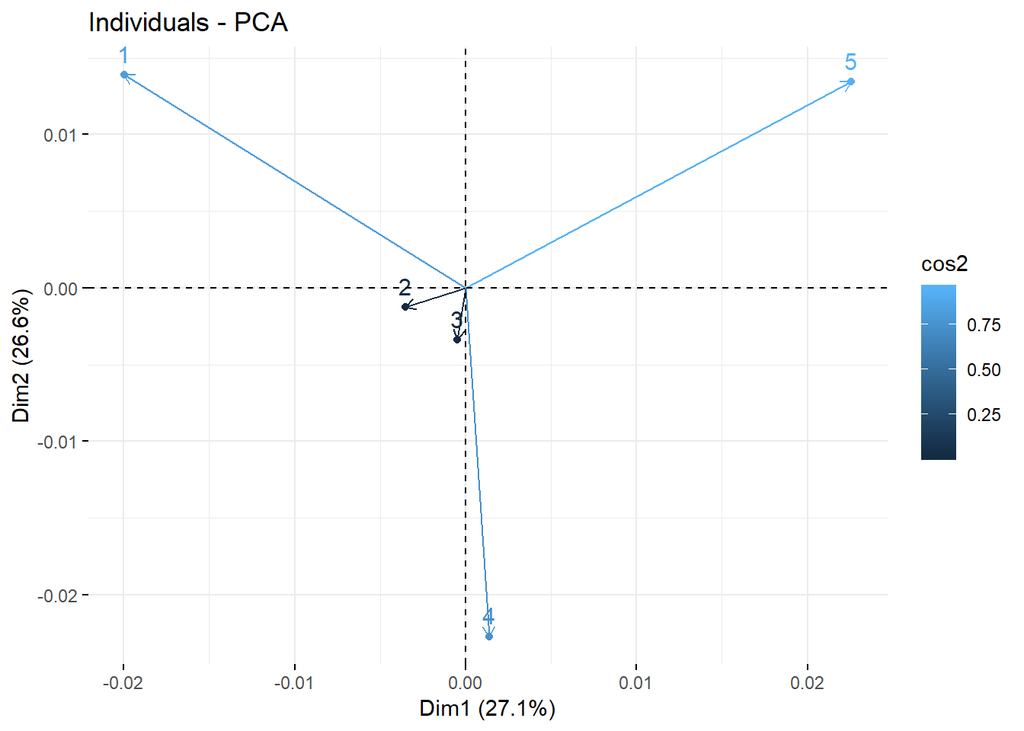

```r
#文章
fviz_pca_ind(pcat, geom= c("point","text","arrow"), col.ind = "cos2")
```

成功將原本一萬多維的資料表示在二維平面上！

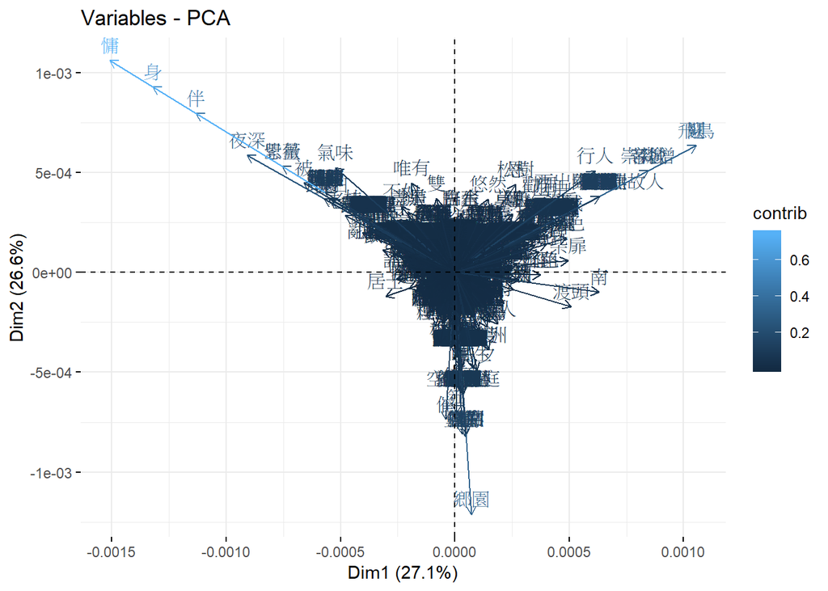

```r
#特徵
fviz_pca_var(pcat, col.var = "contrib")
```

可以發現散的越開的字，就是在文字雲中比較大的字

## KMeans

1. Choosing K

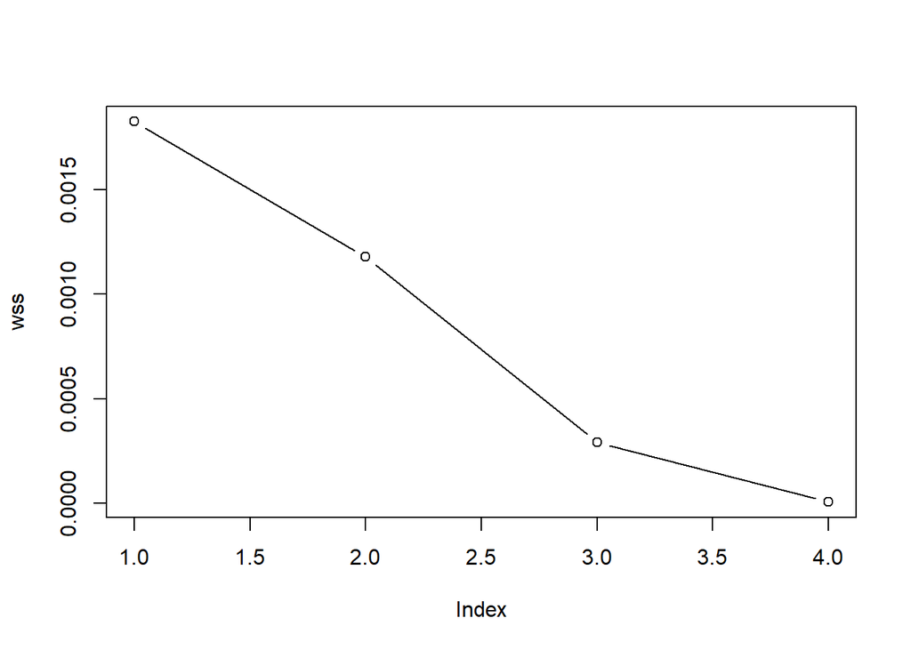

```r
docs.ind <- get_pca_ind(pcat)
ind.coord2 <- docs.ind$coord[, 1:2]
wss <- c()
for (i in 1:4) { wss[i] <- kmeans(ind.coord2, i)$tot.withinss }
plot(wss, type = "b")
```

沒有明顯彎曲，k=3時略有小曲折

2. 分群(取 k = 2)

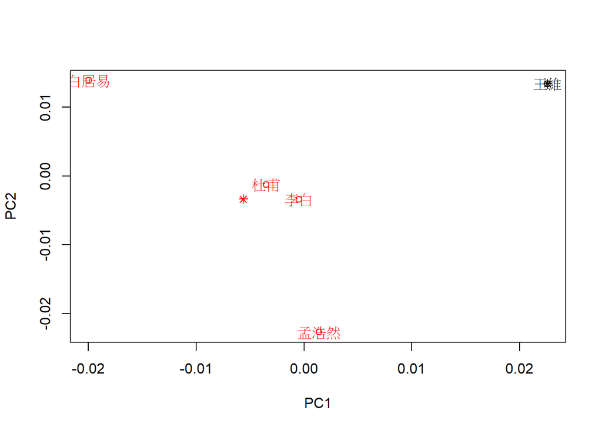

```r
kmeansData = pcat$x[,1:2]
rownames(kmeansData) <- c('白居易','杜甫','李白','孟浩然','王維')

cl <- kmeans(kmeansData, 2)
plot(kmeansData, col = cl$cluster)
text(kmeansData, labels = rownames(kmeansData), col = cl$cluster)
points(cl$centers, col = 1:2, pch = 8, cex = 1) # pch 點樣式, cex 點大小
```

3. 分群(取 k = 3)

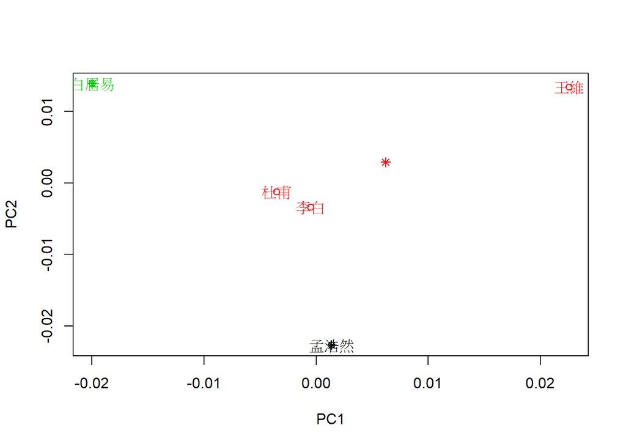

```r
cl <- kmeans(kmeansData, 3)
plot(kmeansData, col = cl$cluster)
text(kmeansData, labels = rownames(kmeansData), col = cl$cluster)
points(cl$centers, col = 1:3, pch = 8, cex = 1) # pch 點樣式, cex 點大小
```

4. 分群(取 k = 4)

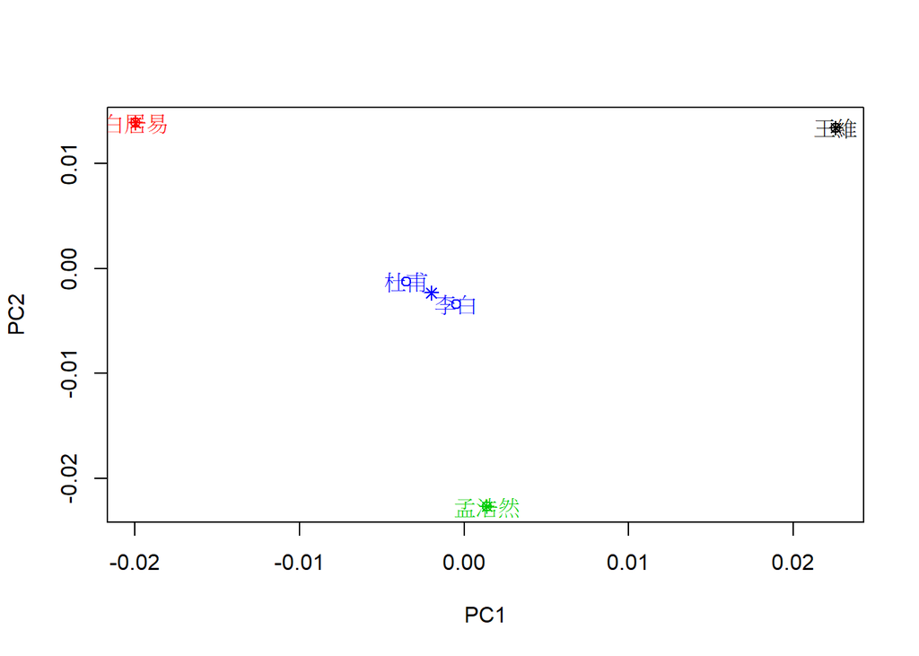

```r
cl <- kmeans(kmeansData, 4)
plot(kmeansData, col = cl$cluster)
text(kmeansData, labels = rownames(kmeansData), col = cl$cluster)
points(cl$centers, col = 1:4, pch = 8, cex = 1) # pch 點樣式, cex 點大小
```

3. 結論與心得
- 由於KMeans每次都隨機選取起始的中心點，導致每一次分群的結果都會不太一樣
- 原先預想得到的結果是可以將詩人的派別區分出來，像是；社會派的杜甫、白居易，田園派的王維、孟浩然和浪漫派的李白，不過結果並分如此，反倒是李白和杜甫非常地靠近，也算是見證了他們的友誼啦！
- 因為在資料收集和處理上花了一些功夫，若能將各作者詩數量增加，並加入更多不同時期的詩人，也許會有更驚人的結果